# Introduction

The next notebook contains the modeling process for the adherence effect. The purpose of this exercise is to estimate the best model based on the most discriminant variables to maximize the estimation metrics.

As we mentioned before, the adherence is how patients of chronic asthma are following the medication prescription. Since the study population is patients in a risk health status, the adherence rate to treatment is high, (around 79% of adherence).

## Libraries

Next libraries are needed to proceed with the initial data preparation and the estimation model.

```python
import pandas as pd
import numpy as np
import seaborn as sns
import matplotlib.pyplot as plt
from IPython.core import display as ICD
from IPython.display import display


%matplotlib inline
plt.style.use('ggplot')

import warnings
warnings.filterwarnings('ignore')
```

## Import Adjusted Data

The results of the data engineer and the cleaning process provide a data frame with relevant and constructed variables. before we proceed to estimate any models, inspection and some variable adjustments are performed.

```python
df = pd.read_csv('Train_AdherenciaNew_20_jun_AG_V2.csv')
list(df.columns)
```

```
['Unnamed: 0',
 'ID_PACIENTE',
 'FE_ENTREVISTA',
 'MORISKY_GREEN',
 'SMAQ1',
 'SMAQ2',
 'ESPA',
 'NM_ESPA',
 'CUALITATIVO_PONDERADO',
 'CUANTITATIVO_PONDERADO',
 'SEX',
 'DEPARTMENT',
 'CITY',
 'STRATUM',
 'SOCIOECONOMIC_LEVEL',
 'AFFILIATION_TYPE',
 'BIRTHDATE',
 'Education',
 'MaritalStatus',
 'LifeCyle',
 'WorkingStatus',
 'Zone',
 'Ocupation',
 'Edad',
 'FE_REGISTRO',
 'Alcohol',
 'Exercise',
 'Mood',
 'Pets',
 'Tobacco',
 'MEDICAMENTO_SOSPECHOSO_Actual',
 'FECHA_INICIO_REACCION_Actual',
 'Ram',
 'MEDICAMENTO_SOSPECHOSO_Anterior',
 'FECHA_INICIO_REACCION_Anterior',
 'Dias desde RAM',
 'FE_ALTA',
 'Entorno',
 'Psicologico',
 'Relaciones interpersonales',
```

[output cut: 30 more lines]

```
 'DiagnosticoAsma',
 'RinitisAlergica',
 'Urticaria',
 'Tumor',
 'Circulatorio',
 'Digestivo',
 'RespiratorioNoAsmaRinitis',
 'Otros',
 'FE_ACTUALIZA',
 'TiempoEntreFormulas6m_Oral',
 'TiempoEsperadoEntreFormulas6m_Oral',
 'Ratio6m_Oral',
 'TiempoEntreFormulas12m_Oral',
 'TiempoEsperadoEntreFormulas12m_Oral',
 'Ratio12m_Oral']
```

```python
#########################################
###   Review the objetive variable.   ###
#########################################

df.CUALITATIVO_PONDERADO.value_counts()
```

```
ADHERENTE       2937
NO ADHERENTE     753
NO APLICA        345
Name: CUALITATIVO_PONDERADO, dtype: int64
```

```python
##########################################
###   Create a binary target varible   ###
##########################################

df['target'] = df['CUALITATIVO_PONDERADO'].apply(lambda x : 1 if x == 'ADHERENTE' else 0) # Convert to numeric
```

```python
df.head(5)
```

|  | Unnamed: 0 | ID_PACIENTE | FE_ENTREVISTA | MORISKY_GREEN | SMAQ1 | SMAQ2 | ESPA | NM_ESPA | CUALITATIVO_PONDERADO | CUANTITATIVO_PONDERADO | ... | RespiratorioNoAsmaRinitis | Otros | FE_ACTUALIZA | TiempoEntreFormulas6m_Oral | TiempoEsperadoEntreFormulas6m_Oral | Ratio6m_Oral | TiempoEntreFormulas12m_Oral | TiempoEsperadoEntreFormulas12m_Oral | Ratio12m_Oral | target |
| --- | --- | --- | --- | --- | --- | --- | --- | --- | --- | --- | --- | --- | --- | --- | --- | --- | --- | --- | --- | --- | --- |
| 0 | 2 | 529410 | 2012-04-19 00:00:00 | NO ADHERENTE | ADHERENTE | 95-100% | NO ADHERENTE | 6 | NO ADHERENTE | 95-100% | ... | 1.0 | 1.0 | 2011-08-03 00:00:00 | 0.0 | 0.0 | NaN | 0.0 | 0.0 | NaN | 0 |
| 1 | 4 | 1198956 | 2012-05-16 00:00:00 | NO ADHERENTE | ADHERENTE | 95-100% | NO ADHERENTE | 6 | NO ADHERENTE | 95-100% | ... | 0.0 | 1.0 | 2012-02-28 00:00:00 | 0.0 | 0.0 | NaN | 0.0 | 0.0 | NaN | 0 |
| 2 | 7 | 605968 | 2012-05-17 00:00:00 | NO ADHERENTE | ADHERENTE | 95-100% | NO ADHERENTE | 5 | NO ADHERENTE | 95-100% | ... | 0.0 | 0.0 | 2012-05-15 00:00:00 | 0.0 | 0.0 | NaN | 0.0 | 0.0 | NaN | 0 |
| 3 | 11 | 730790 | 2012-05-29 00:00:00 | NO ADHERENTE | ADHERENTE | 95-100% | NO ADHERENTE | 5 | NO ADHERENTE | 95-100% | ... | 1.0 | 1.0 | 2012-05-29 00:00:00 | 0.0 | 0.0 | NaN | 0.0 | 0.0 | NaN | 0 |
| 4 | 6 | 1676414 | 2012-05-30 00:00:00 | NO ADHERENTE | ADHERENTE | 95-100% | NO ADHERENTE | 5 | NO ADHERENTE | 95-100% | ... | 0.0 | 0.0 | 2012-05-22 00:00:00 | 0.0 | 0.0 | NaN | 0.0 | 0.0 | NaN | 0 |

5 rows × 86 columns

## Select First Features

In the section, features like dates, identification, redundant, and variables are discarded, categorical and continuous variables are preserver for analysis. Also, a patient without a state of adherence/not adherence is removed and we identify them as indeterminate.

```python
var = [
'ID_PACIENTE',
'CUALITATIVO_PONDERADO',
'SEX',
'STRATUM',
'SOCIOECONOMIC_LEVEL',
'AFFILIATION_TYPE',
'Education',
'MaritalStatus',
'LifeCyle',
'WorkingStatus',
'Zone',
'Ocupation',
'Edad',
'Alcohol',
'Exercise',
'Mood',
'Pets',
'Tobacco',
'MEDICAMENTO_SOSPECHOSO_Anterior',
'Dias desde RAM',
'Entorno',
'Psicologico',
'Relaciones interpersonales',
'Salud fisica',
'ACT_NM_PUNTAJE',
'NM_IMC',
'NM_PESO',
'NM_TALLA',
'ClasificacionImcIngles',
'DiasUCIUltimoAnio',
'DiasUCEUltimoAnio',
'NumHospUltimoAnio',
'DiasUCIRespUltimoAnio',
'DiasUCERespUltimoAnio',
'NumHospRespUltimoAnio',
'NumAdherencias_1_anio',
'NumEntrevistas_1_anio',
'NumNA_1_anio',
'NumNoAdherencias_1_anio',
'PropAdherencia_1_anio',
'NumAdherencias_3_anio',
'NumEntrevistas_3_anio',
'NumNA_3_anio',
'NumNoAdherencias_3_anio',
'PropAdherencia_3_anio',
'NumAdherencias_5_anio',
'NumEntrevistas_5_anio',
'NumNA_5_anio',
'NumNoAdherencias_5_anio',
'PropAdherencia_5_anio',
'DiagnosticoAsma',
'RinitisAlergica',
'Urticaria',
'Tumor',
'Circulatorio',
'Digestivo',
'RespiratorioNoAsmaRinitis',
'Otros',
'TiempoEntreFormulas6m_Oral',
'TiempoEsperadoEntreFormulas6m_Oral',
'Ratio6m_Oral',
'TiempoEntreFormulas12m_Oral',
'TiempoEsperadoEntreFormulas12m_Oral',
'Ratio12m_Oral',
'target']
```

```python
#########################################
###   filter indeterminated patient   ###
#########################################

bd = df[df.CUALITATIVO_PONDERADO != 'NO APLICA'][var]
print(bd.shape)
bd.head()
```

```
(3690, 65)
```

|  | ID_PACIENTE | CUALITATIVO_PONDERADO | SEX | STRATUM | SOCIOECONOMIC_LEVEL | AFFILIATION_TYPE | Education | MaritalStatus | LifeCyle | WorkingStatus | ... | Digestivo | RespiratorioNoAsmaRinitis | Otros | TiempoEntreFormulas6m_Oral | TiempoEsperadoEntreFormulas6m_Oral | Ratio6m_Oral | TiempoEntreFormulas12m_Oral | TiempoEsperadoEntreFormulas12m_Oral | Ratio12m_Oral | target |
| --- | --- | --- | --- | --- | --- | --- | --- | --- | --- | --- | --- | --- | --- | --- | --- | --- | --- | --- | --- | --- | --- |
| 0 | 529410 | NO ADHERENTE | F | 3 | A | BENEFICIARIO | Highschool | Single | Young adult | Minor | ... | 0.0 | 1.0 | 1.0 | 0.0 | 0.0 | NaN | 0.0 | 0.0 | NaN | 0 |
| 1 | 1198956 | NO ADHERENTE | F | 3 | A | BENEFICIARIO | Elementary | Single | Teenager | Minor | ... | 0.0 | 0.0 | 1.0 | 0.0 | 0.0 | NaN | 0.0 | 0.0 | NaN | 0 |
| 2 | 605968 | NO ADHERENTE | F | 1 | A | BENEFICIARIO | Highschool | Free union | Adult | Unemployed | ... | 0.0 | 0.0 | 0.0 | 0.0 | 0.0 | NaN | 0.0 | 0.0 | NaN | 0 |
| 3 | 730790 | NO ADHERENTE | F | 4 | B | BENEFICIARIO | Elementary | Married | Adult | Unemployed | ... | 0.0 | 1.0 | 1.0 | 0.0 | 0.0 | NaN | 0.0 | 0.0 | NaN | 0 |
| 4 | 1676414 | NO ADHERENTE | F | 3 | A | BENEFICIARIO | Highschool | Married | Adult | Employee | ... | 0.0 | 0.0 | 0.0 | 0.0 | 0.0 | NaN | 0.0 | 0.0 | NaN | 0 |

5 rows × 65 columns

## Information Value Original Variables

Since some variables don't explain or discriminated against the adherence rate, a feature selection is proposed using the information value. This indicator identifies which variables have a better discrimination power to differentiated the adherence rate. But first, some graphs and contingency tables are calculated to understand our available data.

```python
def graph_fun(data,var,v = False):
    aux = data.groupby([var,'target'])[['ID_PACIENTE']].count().reset_index().rename(columns={'ID_PACIENTE':'Nro'})
    with sns.color_palette("cubehelix", 8):
        if v == True:
            sns.catplot(y = var, x = "Nro", hue="target", kind="bar", data = aux);
        else:
            sns.catplot(x = var, y = "Nro", hue="target", kind="bar", data = aux);
```

```python
def pivot_tabla(data,var):
    total = len(data.target)
    table = pd.pivot_table(data,index = var,values = ['target','ID_PACIENTE'],aggfunc={'target':np.mean,'ID_PACIENTE':'count'}).rename(columns={'target':'Nro','ID_PACIENTE':'%Adh'}).reset_index()
    table['%Part'] = table['Nro']/total
    return display(table[[var,'Nro','%Part','%Adh']].sort_values(by='%Adh',ascending = False))
```

### Categorical Variables

For simplicity of the exercise, categorical and continuous variables are separated.

```python
cat_var = ['SEX',
'SOCIOECONOMIC_LEVEL',
'AFFILIATION_TYPE',
'Education',
'MaritalStatus',
'LifeCyle',
'WorkingStatus',
'Zone',
'Ocupation',
'Alcohol',
'Exercise',
'Mood',
'Pets',
'Tobacco',
'MEDICAMENTO_SOSPECHOSO_Anterior',
'ClasificacionImcIngles']
```

```python
cat_df = bd[cat_var].fillna("Not-Info")
```

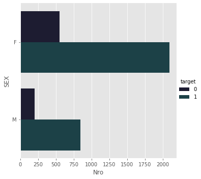

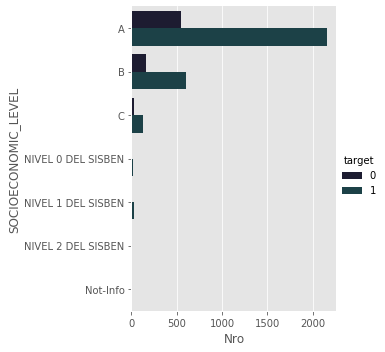

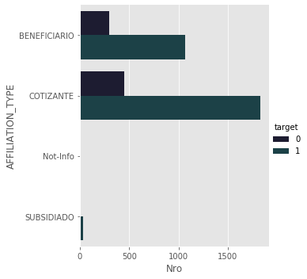

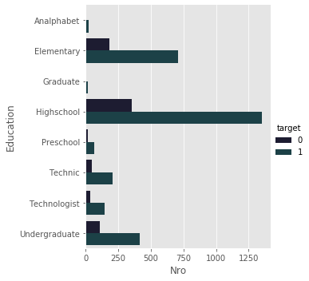

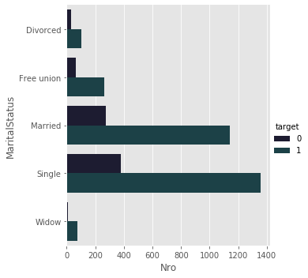

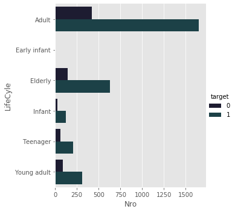

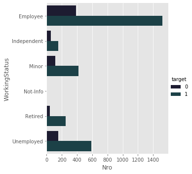

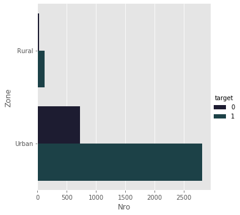

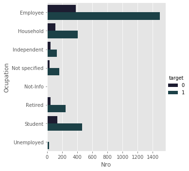

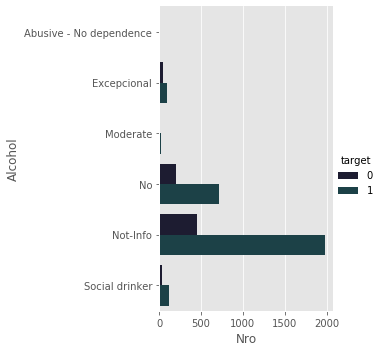

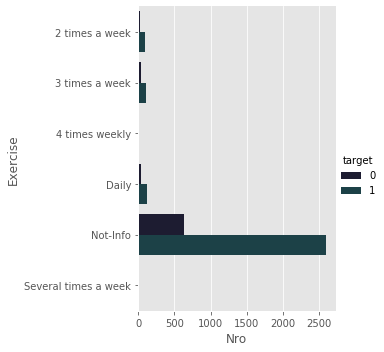

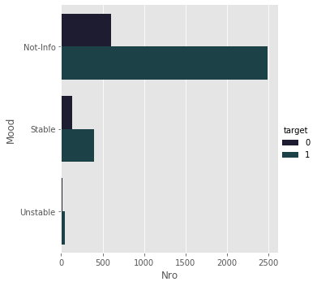

[4 more figures not shown]

```python
for var in cat_var:
    graph_fun(pd.concat([cat_df,bd[['ID_PACIENTE','target']]], axis =1),var,v = True)
```

```python
for var in cat_var:
    pivot_tabla(pd.concat([cat_df,bd[['ID_PACIENTE','target']]], axis =1),var)
```

|  | SEX | Nro | %Part | %Adh |
| --- | --- | --- | --- | --- |
| 0 | F | 0.791304 | 0.000214 | 2645 |
| 1 | M | 0.807656 | 0.000219 | 1045 |

|  | SOCIOECONOMIC_LEVEL | Nro | %Part | %Adh |
| --- | --- | --- | --- | --- |
| 0 | A | 0.797412 | 0.000216 | 2705 |
| 1 | B | 0.784314 | 0.000213 | 765 |
| 2 | C | 0.809816 | 0.000219 | 163 |
| 4 | NIVEL 1 DEL SISBEN | 0.892857 | 0.000242 | 28 |
| 3 | NIVEL 0 DEL SISBEN | 0.789474 | 0.000214 | 19 |
| 6 | Not-Info | 1.000000 | 0.000271 | 6 |
| 5 | NIVEL 2 DEL SISBEN | 0.500000 | 0.000136 | 4 |

|  | AFFILIATION_TYPE | Nro | %Part | %Adh |
| --- | --- | --- | --- | --- |
| 1 | COTIZANTE | 0.801667 | 0.000217 | 2279 |
| 0 | BENEFICIARIO | 0.783566 | 0.000212 | 1363 |
| 3 | SUBSIDIADO | 0.857143 | 0.000232 | 42 |
| 2 | Not-Info | 1.000000 | 0.000271 | 6 |

|  | Education | Nro | %Part | %Adh |
| --- | --- | --- | --- | --- |
| 3 | Highschool | 0.791691 | 0.000215 | 1709 |
| 1 | Elementary | 0.795073 | 0.000215 | 893 |
| 7 | Undergraduate | 0.793499 | 0.000215 | 523 |
| 5 | Technic | 0.807087 | 0.000219 | 254 |
| 6 | Technologist | 0.793478 | 0.000215 | 184 |
| 4 | Preschool | 0.821429 | 0.000223 | 84 |
| 0 | Analphabet | 0.960000 | 0.000260 | 25 |
| 2 | Graduate | 0.833333 | 0.000226 | 18 |

|  | MaritalStatus | Nro | %Part | %Adh |
| --- | --- | --- | --- | --- |
| 3 | Single | 0.782785 | 0.000212 | 1731 |
| 2 | Married | 0.807638 | 0.000219 | 1414 |
| 1 | Free union | 0.798780 | 0.000216 | 328 |
| 0 | Divorced | 0.764706 | 0.000207 | 136 |
| 4 | Widow | 0.913580 | 0.000248 | 81 |

|  | LifeCyle | Nro | %Part | %Adh |
| --- | --- | --- | --- | --- |
| 0 | Adult | 0.794995 | 0.000215 | 2078 |
| 2 | Elderly | 0.811538 | 0.000220 | 780 |
| 5 | Young adult | 0.773399 | 0.000210 | 406 |
| 4 | Teenager | 0.778598 | 0.000211 | 271 |
| 3 | Infant | 0.818182 | 0.000222 | 154 |
| 1 | Early infant | 1.000000 | 0.000271 | 1 |

|  | WorkingStatus | Nro | %Part | %Adh |
| --- | --- | --- | --- | --- |
| 0 | Employee | 0.798637 | 0.000216 | 1907 |
| 5 | Unemployed | 0.791105 | 0.000214 | 742 |
| 2 | Minor | 0.783427 | 0.000212 | 531 |
| 4 | Retired | 0.847458 | 0.000230 | 295 |
| 1 | Independent | 0.741627 | 0.000201 | 209 |
| 3 | Not-Info | 1.000000 | 0.000271 | 6 |

|  | Zone | Nro | %Part | %Adh |
| --- | --- | --- | --- | --- |
| 1 | Urban | 0.794640 | 0.000215 | 3545 |
| 0 | Rural | 0.827586 | 0.000224 | 145 |

|  | Ocupation | Nro | %Part | %Adh |
| --- | --- | --- | --- | --- |
| 0 | Employee | 0.797441 | 0.000216 | 1876 |
| 6 | Student | 0.774247 | 0.000210 | 598 |
| 1 | Household | 0.788054 | 0.000214 | 519 |
| 5 | Retired | 0.841379 | 0.000228 | 290 |
| 3 | Not specified | 0.834197 | 0.000226 | 193 |
| 2 | Independent | 0.738636 | 0.000200 | 176 |
| 7 | Unemployed | 0.875000 | 0.000237 | 32 |
| 4 | Not-Info | 1.000000 | 0.000271 | 6 |

|  | Alcohol | Nro | %Part | %Adh |
| --- | --- | --- | --- | --- |
| 4 | Not-Info | 0.813065 | 0.000220 | 2434 |
| 3 | No | 0.775244 | 0.000210 | 921 |
| 5 | Social drinker | 0.738562 | 0.000200 | 153 |
| 1 | Excepcional | 0.673611 | 0.000183 | 144 |
| 2 | Moderate | 0.888889 | 0.000241 | 27 |
| 0 | Abusive - No dependence | 0.909091 | 0.000246 | 11 |

|  | Exercise | Nro | %Part | %Adh |
| --- | --- | --- | --- | --- |
| 4 | Not-Info | 0.803030 | 0.000218 | 3234 |
| 3 | Daily | 0.744048 | 0.000202 | 168 |
| 1 | 3 times a week | 0.734266 | 0.000199 | 143 |
| 0 | 2 times a week | 0.784483 | 0.000213 | 116 |
| 5 | Several times a week | 0.600000 | 0.000163 | 15 |
| 2 | 4 times weekly | 0.714286 | 0.000194 | 14 |

|  | Mood | Nro | %Part | %Adh |
| --- | --- | --- | --- | --- |
| 0 | Not-Info | 0.805941 | 0.000218 | 3097 |
| 1 | Stable | 0.744318 | 0.000202 | 528 |
| 2 | Unstable | 0.738462 | 0.000200 | 65 |

|  | Pets | Nro | %Part | %Adh |
| --- | --- | --- | --- | --- |
| 5 | Not-Info | 0.807428 | 0.000219 | 2908 |
| 4 | No | 0.755274 | 0.000205 | 474 |
| 2 | Dog(s) | 0.755556 | 0.000205 | 135 |
| 0 | Bird(s) | 0.712121 | 0.000193 | 66 |
| 1 | Cat(s) | 0.806452 | 0.000219 | 62 |
| 6 | Yes | 0.666667 | 0.000181 | 33 |
| 3 | Fish | 0.833333 | 0.000226 | 12 |

|  | Tobacco | Nro | %Part | %Adh |
| --- | --- | --- | --- | --- |
| 4 | Not-Info | 0.819105 | 0.000222 | 2167 |
| 3 | No | 0.756006 | 0.000205 | 1332 |
| 2 | <5 daily | 0.703704 | 0.000191 | 54 |
| 5 | Pasive | 0.872340 | 0.000236 | 47 |
| 1 | 6-15 daily | 0.864865 | 0.000234 | 37 |
| 6 | Yes | 0.750000 | 0.000203 | 36 |
| 0 | 16+ daily | 1.000000 | 0.000271 | 17 |

|  | MEDICAMENTO_SOSPECHOSO_Anterior | Nro | %Part | %Adh |
| --- | --- | --- | --- | --- |
| 11 | Not-Info | 0.791667 | 0.000215 | 2976 |
| 12 | OMALIZUMAB 150 MG/ 1.2 ML POLVO PARA RECONSTIT... | 0.798291 | 0.000216 | 585 |
| 13 | OMALIZUMAB 150MG /1ML SLN INYECTABLE | 0.875000 | 0.000237 | 32 |
| 1 | BENRALIZUMAB 30MG + SLN INYECTABLE | 0.952381 | 0.000258 | 21 |
| 9 | INMUNOGLOBULINA HUMANA 6 G POLVO PARA RECONSTI... | 0.736842 | 0.000200 | 19 |
| 0 | BECLOMETASONA DIPROPIONATO 50 MCG SPRAY NASAL | 1.000000 | 0.000271 | 11 |
| 7 | FORMOTEROL FUMARATO + BUDESONIDA 320 MCG + 9 ... | 0.500000 | 0.000136 | 10 |
| 8 | INMUNOGLOBINA G HUMANA NORMAL 50 MG/ML POLVO P... | 1.000000 | 0.000271 | 9 |
| 3 | DUPILUMAB 200 MG 200 MG + SOLUCION INYECTABLE | 1.000000 | 0.000271 | 6 |
| 6 | FORMOTEROL FUMARATO + BUDESONIDA 160 MCG + 4.... | 1.000000 | 0.000271 | 5 |
| 10 | MEPOLIZUMAB 100 MG POLVO PARA SOLUCIÓN INYECTABLE | 1.000000 | 0.000271 | 5 |
| 5 | FEXOFENADINA 180 MG 180 MG + TABLETA RECUBIERTA | 1.000000 | 0.000271 | 4 |
| 15 | SALMETEROL XINAFOATO + FLUTICASONA PROPIONATO ... | 1.000000 | 0.000271 | 3 |
| 14 | OMALIZUMAB SOLUCIÓN INYECTABLE 150MG /1ML (XOL... | 1.000000 | 0.000271 | 2 |
| 2 | CICLOSPORINA 50 MG/ML SOLUCION INYECTABLE | 1.000000 | 0.000271 | 1 |
| 4 | DUPILUMAB 300MG/2ML JERINGA PRELLENA (DUPIXENT... | 1.000000 | 0.000271 | 1 |

|  | ClasificacionImcIngles | Nro | %Part | %Adh |
| --- | --- | --- | --- | --- |
| 0 | Normal | 0.778448 | 0.000211 | 1327 |
| 2 | Overweight | 0.767992 | 0.000208 | 1056 |
| 1 | Not-Info | 0.903166 | 0.000245 | 537 |
| 3 | Type I obesity | 0.787179 | 0.000213 | 390 |
| 6 | Underweight | 0.773519 | 0.000210 | 287 |
| 4 | Type II obesity | 0.838235 | 0.000227 | 68 |
| 5 | Type III obesity | 0.880000 | 0.000238 | 25 |

```python
# Information Value Funtion

# import packages
import pandas as pd
import numpy as np
import pandas.core.algorithms as algos
from pandas import Series
import scipy.stats.stats as stats
import re
import traceback
import string

max_bin = 20
force_bin = 3

# define a binning function
def mono_bin(Y, X, n = max_bin):

    df1 = pd.DataFrame({"X": X, "Y": Y})
    justmiss = df1[['X','Y']][df1.X.isnull()]
    notmiss = df1[['X','Y']][df1.X.notnull()]
    r = 0
    while np.abs(r) < 1:
        try:
            d1 = pd.DataFrame({"X": notmiss.X, "Y": notmiss.Y, "Bucket": pd.qcut(notmiss.X, n)})
            d2 = d1.groupby('Bucket', as_index=True)
            r, p = stats.spearmanr(d2.mean().X, d2.mean().Y)
            n = n - 1
        except Exception as e:
            n = n - 1

    if len(d2) == 1:
        n = force_bin
        bins = algos.quantile(notmiss.X, np.linspace(0, 1, n))
        if len(np.unique(bins)) == 2:
            bins = np.insert(bins, 0, 1)
            bins[1] = bins[1]-(bins[1]/2)
        d1 = pd.DataFrame({"X": notmiss.X, "Y": notmiss.Y, "Bucket": pd.cut(notmiss.X, np.unique(bins),include_lowest=True)})
        d2 = d1.groupby('Bucket', as_index=True)

    d3 = pd.DataFrame({},index=[])
    d3["MIN_VALUE"] = d2.min().X
    d3["MAX_VALUE"] = d2.max().X
    d3["COUNT"] = d2.count().Y
    d3["EVENT"] = d2.sum().Y
    d3["NONEVENT"] = d2.count().Y - d2.sum().Y
    d3=d3.reset_index(drop=True)

    if len(justmiss.index) > 0:
        d4 = pd.DataFrame({'MIN_VALUE':np.nan},index=[0])
        d4["MAX_VALUE"] = np.nan
        d4["COUNT"] = justmiss.count().Y
        d4["EVENT"] = justmiss.sum().Y
        d4["NONEVENT"] = justmiss.count().Y - justmiss.sum().Y
        d3 = d3.append(d4,ignore_index=True)

    d3["EVENT_RATE"] = d3.EVENT/d3.COUNT
    d3["NON_EVENT_RATE"] = d3.NONEVENT/d3.COUNT
    d3["DIST_EVENT"] = d3.EVENT/d3.sum().EVENT
    d3["DIST_NON_EVENT"] = d3.NONEVENT/d3.sum().NONEVENT
    d3["WOE"] = np.log(d3.DIST_EVENT/d3.DIST_NON_EVENT)
    d3["IV"] = (d3.DIST_EVENT-d3.DIST_NON_EVENT)*np.log(d3.DIST_EVENT/d3.DIST_NON_EVENT)
    d3["VAR_NAME"] = "VAR"
    d3 = d3[['VAR_NAME','MIN_VALUE', 'MAX_VALUE', 'COUNT', 'EVENT', 'EVENT_RATE', 'NONEVENT', 'NON_EVENT_RATE', 'DIST_EVENT','DIST_NON_EVENT','WOE', 'IV']]
    d3 = d3.replace([np.inf, -np.inf], 0)
    d3.IV = d3.IV.sum()

    return(d3)

def char_bin(Y, X):

    df1 = pd.DataFrame({"X": X, "Y": Y})
    justmiss = df1[['X','Y']][df1.X.isnull()]
    notmiss = df1[['X','Y']][df1.X.notnull()]
    df2 = notmiss.groupby('X',as_index=True)

    d3 = pd.DataFrame({},index=[])
    d3["COUNT"] = df2.count().Y
    d3["MIN_VALUE"] = df2.sum().Y.index
    d3["MAX_VALUE"] = d3["MIN_VALUE"]
    d3["EVENT"] = df2.sum().Y
    d3["NONEVENT"] = df2.count().Y - df2.sum().Y

    if len(justmiss.index) > 0:
        d4 = pd.DataFrame({'MIN_VALUE':np.nan},index=[0])
        d4["MAX_VALUE"] = np.nan
        d4["COUNT"] = justmiss.count().Y
        d4["EVENT"] = justmiss.sum().Y
        d4["NONEVENT"] = justmiss.count().Y - justmiss.sum().Y
        d3 = d3.append(d4,ignore_index=True)

    d3["EVENT_RATE"] = d3.EVENT/d3.COUNT
    d3["NON_EVENT_RATE"] = d3.NONEVENT/d3.COUNT
    d3["DIST_EVENT"] = d3.EVENT/d3.sum().EVENT
    d3["DIST_NON_EVENT"] = d3.NONEVENT/d3.sum().NONEVENT
    d3["WOE"] = np.log(d3.DIST_EVENT/d3.DIST_NON_EVENT)
    d3["IV"] = (d3.DIST_EVENT-d3.DIST_NON_EVENT)*np.log(d3.DIST_EVENT/d3.DIST_NON_EVENT)
    d3["VAR_NAME"] = "VAR"
    d3 = d3[['VAR_NAME','MIN_VALUE', 'MAX_VALUE', 'COUNT', 'EVENT', 'EVENT_RATE', 'NONEVENT', 'NON_EVENT_RATE', 'DIST_EVENT','DIST_NON_EVENT','WOE', 'IV']]
    d3 = d3.replace([np.inf, -np.inf], 0)
    d3.IV = d3.IV.sum()
    d3 = d3.reset_index(drop=True)

    return(d3)

def data_vars(df1, target):

    stack = traceback.extract_stack()
    filename, lineno, function_name, code = stack[-2]
    vars_name = re.compile(r'\((.*?)\).*$').search(code).groups()[0]
    final = (re.findall(r"[\w']+", vars_name))[-1]

    x = df1.dtypes.index
    count = -1

    for i in x:
        if i.upper() not in (final.upper()):
            if np.issubdtype(df1[i], np.number) and len(Series.unique(df1[i])) > 2:
                conv = mono_bin(target, df1[i])
                conv["VAR_NAME"] = i
                count = count + 1
            else:
                conv = char_bin(target, df1[i])
                conv["VAR_NAME"] = i
                count = count + 1

            if count == 0:
                iv_df = conv
            else:
                iv_df = iv_df.append(conv,ignore_index=True)

    iv = pd.DataFrame({'IV':iv_df.groupby('VAR_NAME').IV.max()})
    iv = iv.reset_index()
    return(iv_df,iv)
```

```python
final_iv, IV = data_vars(cat_df,bd.target)
```

```python
IV.sort_values('IV',ascending=False).head(10)
```

|  | VAR_NAME | IV |
| --- | --- | --- |
| 2 | ClasificacionImcIngles | 0.101189 |
| 13 | Tobacco | 0.043240 |
| 1 | Alcohol | 0.039884 |
| 10 | Pets | 0.022892 |
| 7 | MaritalStatus | 0.022212 |
| 9 | Ocupation | 0.020941 |
| 6 | MEDICAMENTO_SOSPECHOSO_Anterior | 0.019357 |
| 8 | Mood | 0.018562 |
| 4 | Exercise | 0.016730 |
| 14 | WorkingStatus | 0.015932 |

### Continuos Variables

```python
num_var = ['STRATUM',
'Edad',
'Dias desde RAM',
'Entorno',
'Psicologico',
'Relaciones interpersonales',
'Salud fisica',
'ACT_NM_PUNTAJE',
'NM_IMC',
'NM_PESO',
'NM_TALLA',
'DiasUCIUltimoAnio',
'DiasUCEUltimoAnio',
'NumHospUltimoAnio',
'DiasUCIRespUltimoAnio',
'DiasUCERespUltimoAnio',
'NumHospRespUltimoAnio',
'NumAdherencias_1_anio',
'NumEntrevistas_1_anio',
'NumNA_1_anio',
'NumNoAdherencias_1_anio',
'PropAdherencia_1_anio',
'NumAdherencias_3_anio',
'NumEntrevistas_3_anio',
'NumNA_3_anio',
'NumNoAdherencias_3_anio',
'PropAdherencia_3_anio',
'NumAdherencias_5_anio',
'NumEntrevistas_5_anio',
'NumNA_5_anio',
'NumNoAdherencias_5_anio',
'PropAdherencia_5_anio',
'DiagnosticoAsma',
'RinitisAlergica',
'Urticaria',
'Tumor',
'Circulatorio',
'Digestivo',
'RespiratorioNoAsmaRinitis',
'Otros',
'TiempoEntreFormulas6m_Oral',
'TiempoEsperadoEntreFormulas6m_Oral',
'Ratio6m_Oral',
'TiempoEntreFormulas12m_Oral',
'TiempoEsperadoEntreFormulas12m_Oral',
'Ratio12m_Oral']
```

```python
num_df = bd[num_var]
num_df.shape
```

```
(3690, 46)
```

Some scatter plots are shown using as hue the adherence effect with the continuous variables.

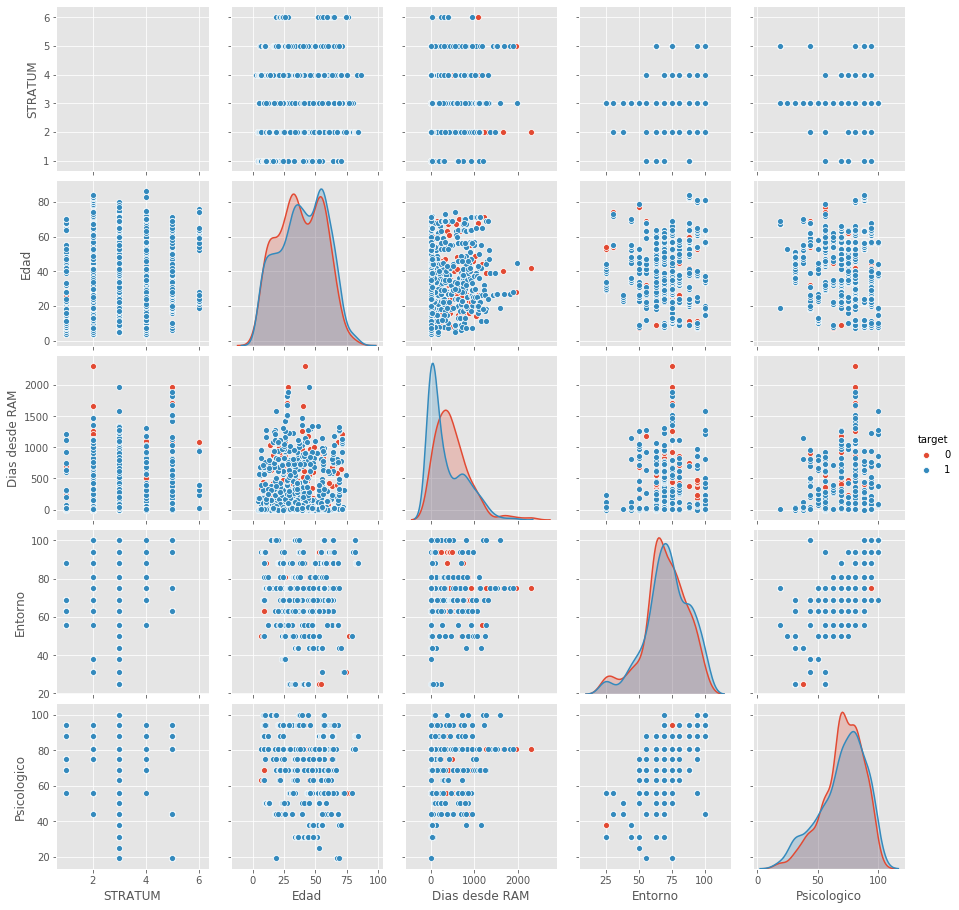

```python
sns.pairplot(pd.concat([aux.iloc[:,0:5],bd[['target']]], axis =1),hue = 'target')
```

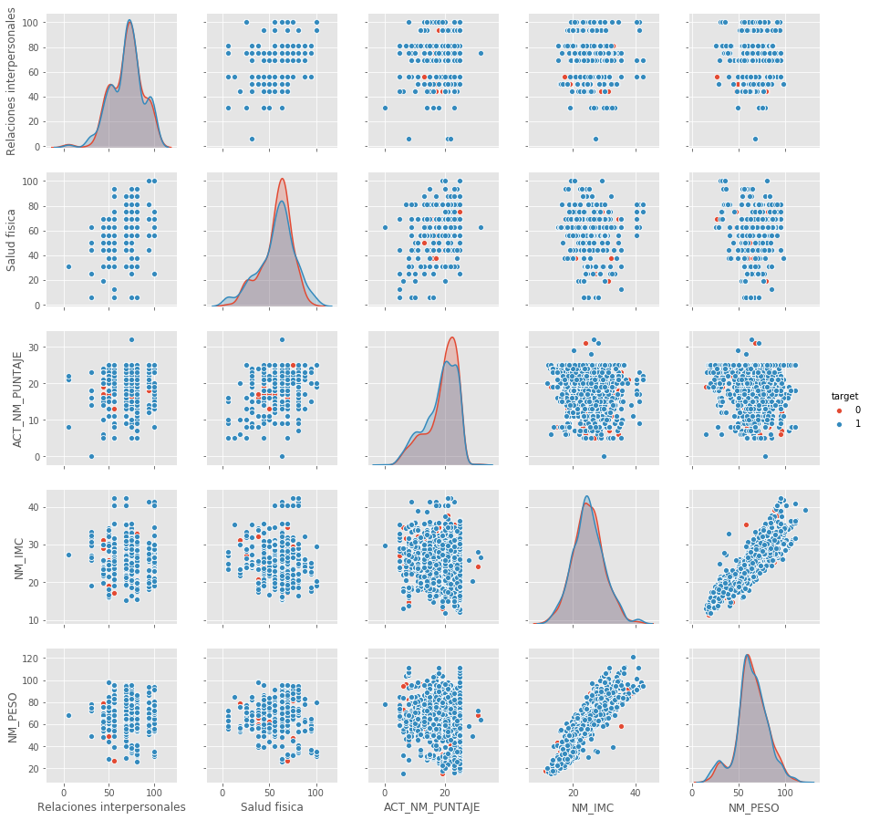

```python
sns.pairplot(pd.concat([aux.iloc[:,5:10],bd[['target']]], axis =1),hue = 'target')
```

```python
##############################################
###   Perform IV for Continuos covariates  ###
##############################################

final_iv, IV = data_vars(num_df,bd.target)
```

```python
IV.sort_values('IV',ascending=False).head(10)
```

|  | VAR_NAME | IV |
| --- | --- | --- |
| 25 | NumNoAdherencias_1_anio | 0.154424 |
| 27 | NumNoAdherencias_5_anio | 0.135751 |
| 26 | NumNoAdherencias_3_anio | 0.135054 |
| 29 | PropAdherencia_1_anio | 0.134577 |
| 31 | PropAdherencia_5_anio | 0.114461 |
| 30 | PropAdherencia_3_anio | 0.113269 |
| 18 | NumEntrevistas_3_anio | 0.107996 |
| 17 | NumEntrevistas_1_anio | 0.101324 |
| 13 | NM_TALLA | 0.101322 |
| 12 | NM_PESO | 0.094714 |

## Select Final Variables

Based on the previous results, covariates with at least 4% of information value are selected to continue with the modeling process.

```python
def_var = [
'CUALITATIVO_PONDERADO',
'Alcohol',
'Tobacco',
'Dias desde RAM',
'ACT_NM_PUNTAJE',
'NM_IMC',
'NumEntrevistas_1_anio',
'NumNoAdherencias_1_anio',
'PropAdherencia_1_anio',
'NumAdherencias_3_anio',
'NumEntrevistas_3_anio',
'NumNoAdherencias_3_anio',
'PropAdherencia_3_anio',
'NumAdherencias_5_anio',
'NumEntrevistas_5_anio',
'NumNoAdherencias_5_anio',
'PropAdherencia_5_anio',
'Ratio6m_Oral',
'target']
```

```python
df_def = bd[def_var]
df_def.head()
```

|  | CUALITATIVO_PONDERADO | Alcohol | Tobacco | Dias desde RAM | ACT_NM_PUNTAJE | NM_IMC | NumEntrevistas_1_anio | NumNoAdherencias_1_anio | PropAdherencia_1_anio | NumAdherencias_3_anio | NumEntrevistas_3_anio | NumNoAdherencias_3_anio | PropAdherencia_3_anio | NumAdherencias_5_anio | NumEntrevistas_5_anio | NumNoAdherencias_5_anio | PropAdherencia_5_anio | Ratio6m_Oral | target |
| --- | --- | --- | --- | --- | --- | --- | --- | --- | --- | --- | --- | --- | --- | --- | --- | --- | --- | --- | --- |
| 0 | NO ADHERENTE | No | No | NaN | NaN | NaN | 0 | 0 | NaN | 0 | 0 | 0 | NaN | 0 | 0 | 0 | NaN | NaN | 0 |
| 1 | NO ADHERENTE | NaN | NaN | NaN | NaN | NaN | 0 | 0 | NaN | 0 | 0 | 0 | NaN | 0 | 0 | 0 | NaN | NaN | 0 |
| 2 | NO ADHERENTE | NaN | NaN | NaN | NaN | NaN | 0 | 0 | NaN | 0 | 0 | 0 | NaN | 0 | 0 | 0 | NaN | NaN | 0 |
| 3 | NO ADHERENTE | NaN | NaN | NaN | NaN | 21.55 | 0 | 0 | NaN | 0 | 0 | 0 | NaN | 0 | 0 | 0 | NaN | NaN | 0 |
| 4 | NO ADHERENTE | NaN | No | NaN | NaN | 24.52 | 0 | 0 | NaN | 0 | 0 | 0 | NaN | 0 | 0 | 0 | NaN | NaN | 0 |

```python
# Shows the adherence rate for the data-

print("Adherence Rate:",df_def.target.mean())
```

```
Adherence Rate: 0.7959349593495935
```

## Missing Information

For null values, some strategies were defined to fill this missing information based on the variable background. For the final selected variables, two different null treatments were chosen. Fill with zeros and fill with the median of the observed variable.

```python
# Adjust Null Values for countiousn variables ZEROS.
```

```python
zero = ['Dias desde RAM',
'NumEntrevistas_1_anio',
'NumNoAdherencias_1_anio',
'PropAdherencia_1_anio',
'NumAdherencias_3_anio',
'NumEntrevistas_3_anio',
'NumNoAdherencias_3_anio',
'PropAdherencia_3_anio',
'NumAdherencias_5_anio',
'NumEntrevistas_5_anio',
'NumNoAdherencias_5_anio',
'PropAdherencia_5_anio',
'Ratio6m_Oral']


zero_df = df_def[zero].fillna(0)
```

```python
# Median Adjustment

median = ['NM_IMC']

median_df =  df_def[median]

median_df[median_df.columns] = median_df[median_df.columns].apply(pd.to_numeric, errors='coerce')

median_df = median_df.fillna(median_df.median())
```

Usign the results from IV analysis, ACT variable (numerical) is transformed to a categorial variable.

```python
# Categorize IMC

def ACT_BIN(val):
    if np.isnan(val):
        cat = '0'
    elif val <= 18:
        cat = '1'
    elif val <= 22:
        cat = '2'
    else:
        cat = '3'
    return(cat)
```

```python
df_def['Act_Bin'] = df_def['ACT_NM_PUNTAJE'].apply(ACT_BIN)
```

```python
df_def.Act_Bin.value_counts()
```

```
0    1616
1     790
2     677
3     607
Name: Act_Bin, dtype: int64
```

## One-hot Encoding

For the categorical variables. since them doesn't have an inherent order, a one-hot encoding is used to create binary variables for each one od the categories in a specific covariate.

```python
# Create Dummies for Categorical Variables

cat = ['Alcohol','Tobacco','Act_Bin']

cat_df = df_def[cat]
for var in cat:
    cat_df = pd.get_dummies(cat_df,columns = [var] ,prefix = var+'_',prefix_sep='',drop_first=False)

cat_df.columns
```

```
Index(['Alcohol_Abusive - No dependence', 'Alcohol_Excepcional',
       'Alcohol_Moderate', 'Alcohol_No', 'Alcohol_Social drinker',
       'Tobacco_16+ daily', 'Tobacco_6-15 daily', 'Tobacco_<5 daily',
       'Tobacco_No', 'Tobacco_Pasive', 'Tobacco_Yes', 'Act_Bin_0', 'Act_Bin_1',
       'Act_Bin_2', 'Act_Bin_3'],
      dtype='object')
```

## Final Base to model

After adjusting some covariates, we proceed to concatenate them and create an adjusted data table.

```python
## Join DataFrames

df_mod = pd.concat([cat_df,zero_df,median_df],axis=1)
df_mod.head()
```

|  | Alcohol_Abusive - No dependence | Alcohol_Excepcional | Alcohol_Moderate | Alcohol_No | Alcohol_Social drinker | Tobacco_16+ daily | Tobacco_6-15 daily | Tobacco_<5 daily | Tobacco_No | Tobacco_Pasive | ... | NumAdherencias_3_anio | NumEntrevistas_3_anio | NumNoAdherencias_3_anio | PropAdherencia_3_anio | NumAdherencias_5_anio | NumEntrevistas_5_anio | NumNoAdherencias_5_anio | PropAdherencia_5_anio | Ratio6m_Oral | NM_IMC |
| --- | --- | --- | --- | --- | --- | --- | --- | --- | --- | --- | --- | --- | --- | --- | --- | --- | --- | --- | --- | --- | --- |
| 0 | 0 | 0 | 0 | 1 | 0 | 0 | 0 | 0 | 1 | 0 | ... | 0 | 0 | 0 | 0.0 | 0 | 0 | 0 | 0.0 | 0.0 | 24.91 |
| 1 | 0 | 0 | 0 | 0 | 0 | 0 | 0 | 0 | 0 | 0 | ... | 0 | 0 | 0 | 0.0 | 0 | 0 | 0 | 0.0 | 0.0 | 24.91 |
| 2 | 0 | 0 | 0 | 0 | 0 | 0 | 0 | 0 | 0 | 0 | ... | 0 | 0 | 0 | 0.0 | 0 | 0 | 0 | 0.0 | 0.0 | 24.91 |
| 3 | 0 | 0 | 0 | 0 | 0 | 0 | 0 | 0 | 0 | 0 | ... | 0 | 0 | 0 | 0.0 | 0 | 0 | 0 | 0.0 | 0.0 | 21.55 |
| 4 | 0 | 0 | 0 | 0 | 0 | 0 | 0 | 0 | 1 | 0 | ... | 0 | 0 | 0 | 0.0 | 0 | 0 | 0 | 0.0 | 0.0 | 24.52 |

5 rows × 29 columns

```python
df_mod.shape
```

```
(3690, 29)
```

# Model Estimation.

Now, a machine learning algorithm is chosen to estimate de binary effect of adherence/no adherence. Radom forest is the methodology selected.

```python
# Create objects for estimation.
X = df_mod
y = df_def.target
```

### Libraries Models

```python
from statsmodels.stats.outliers_influence import variance_inflation_factor
from sklearn.model_selection import train_test_split, KFold
from sklearn.metrics import mean_squared_error, r2_score,accuracy_score,average_precision_score,f1_score
from sklearn import linear_model

from sklearn import tree
from sklearn import metrics
from sklearn import neighbors
from sklearn import ensemble
from sklearn.ensemble import RandomForestClassifier,GradientBoostingClassifier
from sklearn.linear_model import LogisticRegression
```

```python
# Split the data in train/test samples.

X_train, X_test, y_train, y_test = train_test_split(X, y, test_size=0.20, random_state = 456)
```

To obtain the best model configuration, an optimization parameter procedure is performed using a Random search with a Cross-Validation strategy.

```python
# Aditional Libraries

from scipy.stats import uniform
from scipy.stats import randint
```

```python
#####################################
###   Parameters to be Optimized  ###
#####################################

param_dist = {"criterion": ["gini", "entropy"]
             ,"max_depth": randint(4,7)
             ,"n_estimators": randint(4,1000)
             ,'ccp_alpha':[0,0.0001,0.0002,0.0003]
            }
```

```python
# Import Function to optimize.

from sklearn.model_selection import RandomizedSearchCV
from time import time
```

```python
# Create the classifier CLF to fit

clf = RandomForestClassifier( n_jobs=-1,random_state=123)
```

```python
# Create the class RandomizedSearchCV to find the configuration.

n_iter_search = 50
random_search = RandomizedSearchCV(clf, param_distributions=param_dist,
                                   n_iter=n_iter_search, cv=5,
                                   n_jobs=-1, verbose=1)
```

```python
# Fit the parameters search.
start = time()
random_search.fit(X_train, y_train)
print("RandomizedSearchCV tomó {} segundos usando {} configuraciones".format(time() - start, n_iter_search))
```

```
Fitting 5 folds for each of 50 candidates, totalling 250 fits
```

```
[Parallel(n_jobs=-1)]: Using backend LokyBackend with 4 concurrent workers.
[Parallel(n_jobs=-1)]: Done  42 tasks      | elapsed:   30.1s
[Parallel(n_jobs=-1)]: Done 192 tasks      | elapsed:  3.9min
[Parallel(n_jobs=-1)]: Done 250 out of 250 | elapsed:  5.1min finished
```

```
RandomizedSearchCV tomó 306.1786472797394 segundos usando 50 configuraciones
```

```python
# Shows the best configuration.

random_search.best_params_
```

```
{'ccp_alpha': 0.0002,
 'criterion': 'entropy',
 'max_depth': 6,
 'n_estimators': 287}
```

```python
# Create the final CLF using a Random forest with the optimized parameters.

clf = RandomForestClassifier(
      criterion = 'entropy',
      ccp_alpha = 0.0002,
      max_depth = 6,
      max_features = 0.8,
      n_estimators = 287,
      n_jobs=-1,
      verbose=1,
      random_state = 2019)

clf.fit(X_train,y_train)
```

```
[Parallel(n_jobs=-1)]: Using backend ThreadingBackend with 4 concurrent workers.
[Parallel(n_jobs=-1)]: Done  42 tasks      | elapsed:    0.1s
[Parallel(n_jobs=-1)]: Done 192 tasks      | elapsed:    1.0s
[Parallel(n_jobs=-1)]: Done 287 out of 287 | elapsed:    1.5s finished
```

```
RandomForestClassifier(bootstrap=True, ccp_alpha=0.0002, class_weight=None,
                       criterion='entropy', max_depth=6, max_features=0.8,
                       max_leaf_nodes=None, max_samples=None,
                       min_impurity_decrease=0.0, min_impurity_split=None,
                       min_samples_leaf=1, min_samples_split=2,
                       min_weight_fraction_leaf=0.0, n_estimators=287,
                       n_jobs=-1, oob_score=False, random_state=2019, verbose=1,
                       warm_start=False)
```

### Feature Importances Random Forest

Since a Random Forest has a high number of trees, feature importance shows how participative a variable is in the methodology.

```python
# Shows top 10 Feature Importances.

importances = clf.feature_importances_
indices = np.argsort(importances)[::-1]

print("Importancia de características:")

for f in range(10):
    print("Característica %s (%f)" % (df_mod.columns[int(indices[f])], importances[indices[f]]))
```

```
Importancia de características:
Característica NM_IMC (0.170589)
Característica Dias desde RAM (0.114506)
Característica NumNoAdherencias_1_anio (0.094571)
Característica Ratio6m_Oral (0.093340)
Característica NumNoAdherencias_3_anio (0.063413)
Característica NumNoAdherencias_5_anio (0.054677)
Característica PropAdherencia_5_anio (0.052317)
Característica NumEntrevistas_5_anio (0.050779)
Característica NumEntrevistas_1_anio (0.046021)
Característica PropAdherencia_3_anio (0.038622)
```

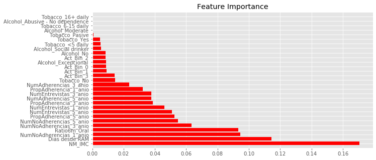

```python
plt.figure(figsize=(10,5))
plt.title("Feature Importance")
plt.barh(range(df_mod.shape[1]), importances[indices],color="r", align="center")

yticks_labels = [df_mod.columns[i] for i in indices]
plt.yticks(range(df_mod.shape[1]), yticks_labels, rotation=0)
plt.ylim([-1, df_mod.shape[1]])
plt.show()
plt.savefig('imp.png')
```

Based on the previous results, NM_IMC (BMI) and the number of days last RAM (negative reaction to medicament) are the most important features in the classifier.

## Estimation Metrics

The next code shows some of the estimation metrics to evaluate algorithm performance.

```python
# Estimate model in the test train/test sample

y_pred = clf.predict(X_test)
y_ = clf.predict(X_train)
```

```
[Parallel(n_jobs=4)]: Using backend ThreadingBackend with 4 concurrent workers.
[Parallel(n_jobs=4)]: Done  42 tasks      | elapsed:    0.0s
[Parallel(n_jobs=4)]: Done 192 tasks      | elapsed:    0.0s
[Parallel(n_jobs=4)]: Done 287 out of 287 | elapsed:    0.1s finished
[Parallel(n_jobs=4)]: Using backend ThreadingBackend with 4 concurrent workers.
[Parallel(n_jobs=4)]: Done  42 tasks      | elapsed:    0.0s
[Parallel(n_jobs=4)]: Done 192 tasks      | elapsed:    0.0s
[Parallel(n_jobs=4)]: Done 287 out of 287 | elapsed:    0.1s finished
```

### Errors Summary

```python
print('Mean Absolute Error:', metrics.mean_absolute_error(y_test, y_pred))
print('Mean Squared Error:', metrics.mean_squared_error(y_test, y_pred))
print('Root Mean Squared Error:', np.sqrt(metrics.mean_squared_error(y_test, y_pred)))
```

```
Mean Absolute Error: 0.1991869918699187
Mean Squared Error: 0.1991869918699187
Root Mean Squared Error: 0.4463036991443368
```

### Model Accuracy

```python
print("Accuracy Train:",accuracy_score(y_train, y_))
print("Accuracy Test:",accuracy_score(y_test, y_pred))
```

```
Accuracy Train: 0.8102981029810298
Accuracy Test: 0.8008130081300813
```

### Recall

```python
print("Recall Train:", average_precision_score(y_train, y_))
print("Reall Test:", average_precision_score(y_test, y_pred))
```

```
Recall Train: 0.8085273795029453
Reall Test: 0.8040750912083364
```

### ROC and AUC Metrics

```python
from sklearn.metrics import roc_curve,roc_auc_score

y_pred = clf.predict_proba(X_test)[:, 1]
fpr_rf, tpr_rf, _ = roc_curve(y_test, y_pred)
```

```
[Parallel(n_jobs=4)]: Using backend ThreadingBackend with 4 concurrent workers.
[Parallel(n_jobs=4)]: Done  42 tasks      | elapsed:    0.0s
[Parallel(n_jobs=4)]: Done 192 tasks      | elapsed:    0.0s
[Parallel(n_jobs=4)]: Done 287 out of 287 | elapsed:    0.0s finished
```

```python
y_pred = clf.predict_proba(X_test)[:,1]
y_ = clf.predict_proba(X_train)[:,1]
```

```
[Parallel(n_jobs=4)]: Using backend ThreadingBackend with 4 concurrent workers.
[Parallel(n_jobs=4)]: Done  42 tasks      | elapsed:    0.0s
[Parallel(n_jobs=4)]: Done 192 tasks      | elapsed:    0.0s
[Parallel(n_jobs=4)]: Done 287 out of 287 | elapsed:    0.0s finished
[Parallel(n_jobs=4)]: Using backend ThreadingBackend with 4 concurrent workers.
[Parallel(n_jobs=4)]: Done  42 tasks      | elapsed:    0.0s
[Parallel(n_jobs=4)]: Done 192 tasks      | elapsed:    0.0s
[Parallel(n_jobs=4)]: Done 287 out of 287 | elapsed:    0.1s finished
```

```python
roc_auc = roc_auc_score(y_test, y_pred)
roc_auc_train = roc_auc_score(y_train, y_)
print("AUC Train Samples:",roc_auc_train)
print("AUC Test Samples:",roc_auc)
```

```
AUC Train Samples: 0.7904122074458133
AUC Test Samples: 0.6687641723356008
```

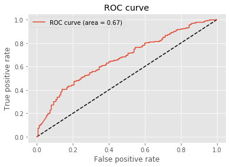

```python
#################################
###   ROC Curve Test Sample   ###
#################################

plt.figure(1)
plt.plot([0, 1], [0, 1], 'k--')
plt.plot(fpr_rf, tpr_rf, label='ROC curve (area = %0.2f)' % roc_auc)
plt.xlabel('False positive rate')
plt.ylabel('True positive rate')
plt.title('ROC curve')
plt.legend(loc='best')
plt.show()
```

### KS - Kolmogorov Smirnov

```python
from scipy import stats

print("test:",stats.ks_2samp(y_pred[y_test==1], y_pred[y_test==0])[0])
print("train:",stats.ks_2samp(y_[y_train==1], y_[y_train==0])[0])
```

```
test: 0.28061224489795916
train: 0.36509025752463736
```

## Export Model

We already have a classification model for adherence to the treatment, now we are exporting the model in order to be able to use it in the prediction of new bases.

```python
import pickle
```

```python
filename = 'Adherence_Model.sav'
pickle.dump(clf, open(filename, 'wb'))
```